# NYC Council Data Science Test - ANALYSIS

Caffrey Lee

2020-01-18

### Introduction:

*The purpose of this document is for the NYC Council Data Science Interview. It is done by Caffrey Lee solely.*

### Description of the data:

#### Given Data :

The given data contains the individual record of the arrest with the following number of observations and the number of features: 4798339 number of observations and 18features. Table 1 provides a glimpse of it, the first 5 rows.

|  | ARREST_KEY | ARREST_DATE | PD_CD | PD_DESC | KY_CD | OFNS_DESC | LAW_CODE | LAW_CAT_CD | ARREST_BORO | ARREST_PRECINCT | JURISDICTION_CODE | AGE_GROUP | PERP_SEX | PERP_RACE | X_COORD_CD | Y_COORD_CD | Latitude | Longitude |
| --- | --- | --- | --- | --- | --- | --- | --- | --- | --- | --- | --- | --- | --- | --- | --- | --- | --- | --- |
| 1 | 173130602 | 2017-12-31 | 566 | MARIJUANA, POSSESSION | 678 | MISCELLANEOUS PENAL LAW | PL 2210500 | V | Q | 105 | 0 | 25-44 | M | BLACK | 1063056 | 207463 | 40.735771803 | -73.715638255 |
| 2 | 173114463 | 2017-12-31 | 478 | THEFT OF SERVICES, UNCLASSIFIED | 343 | OTHER OFFENSES RELATED TO THEFT | PL 1651503 | M | Q | 114 | 0 | 25-44 | M | ASIAN / PACIFIC ISLANDER | 1009113 | 219613 | 40.769436597 | -73.910240711 |
| 3 | 173113513 | 2017-12-31 | 849 | NY STATE LAWS,UNCLASSIFIED VIOLATION | 677 | OTHER STATE LAWS | LOC000000V | V | K | 73 | 1 | 18-24 | M | BLACK | 1010719 | 186857 | 40.679524703 | -73.904571538 |
| 4 | 173113423 | 2017-12-31 | 101 | ASSAULT 3 | 344 | ASSAULT 3 &amp; RELATED OFFENSES | PL 1200001 | M | M | 18 | 0 | 25-44 | M | WHITE | 987831 | 217446 | 40.763522977 | -73.9870744249999 |
| 5 | 173113421 | 2017-12-31 | 101 | ASSAULT 3 | 344 | ASSAULT 3 &amp; RELATED OFFENSES | PL 1200001 | M | M | 18 | 0 | 45-64 | M | BLACK | 987073 | 216078 | 40.759768442 | -73.9898112979999 |

#### Population (NYC OPEN DATA):

Table 2. shows the 2010 population of each borough and the total population of that year. **Please aware that this is manually modified for the analysis**. (source: https://data.cityofnewyork.us/City-Government/New-York-City-Population-By-Community-Districts/xi7c-iiu2))

|  | arrest_boro | 2010_ pop | total |
| --- | --- | --- | --- |
| 1 | B | 1385108 | 8242624 |
| 2 | K | 2552911 | 8242624 |
| 3 | M | 1585873 | 8242624 |
| 4 | Q | 2250002 | 8242624 |
| 5 | S | 468730 | 8242624 |

### Exploring the data:

After exploring the data I found some issues with the data that I need to clean before the analysis:

- *arrest_date is not in a date format;*
- *there are missing values;*
- *some of the unique keys of the categorical variables are not descriptive;*
- *too many categories for a single feature;*

### Data Preperation:

After cleaning the data, the final data that I utilized for the analysis has 4789450 of observations with 20 columns with a missing rate of 0%. In short, the following analysis is based on the *99.81%* of the given data.

#### Imputing missing values

Looking at Table 3, one could see that the entire columns are missing. That is, it is impossible to trace back and impute the values. Also, the missing rates are not critical: **0.19%**. Hence, I decided to simply remove the rows that are missing by dropping the NA values.

|  | ARREST_KEY | ARREST_DATE | PD_CD | PD_DESC | KY_CD | OFNS_DESC | LAW_CODE | LAW_CAT_CD | ARREST_BORO | ARREST_PRECINCT | JURISDICTION_CODE | AGE_GROUP | PERP_SEX | PERP_RACE | X_COORD_CD | Y_COORD_CD | Latitude | Longitude |
| --- | --- | --- | --- | --- | --- | --- | --- | --- | --- | --- | --- | --- | --- | --- | --- | --- | --- | --- |
| 1 |  |  |  |  |  |  |  |  |  |  |  |  |  |  |  |  |  |  |
| 2 |  |  |  |  |  |  |  |  |  |  |  |  |  |  |  |  |  |  |
| 3 |  |  |  |  |  |  |  |  |  |  |  |  |  |  |  |  |  |  |
| 4 |  |  |  |  |  |  |  |  |  |  |  |  |  |  |  |  |  |  |
| 5 |  |  |  |  |  |  |  |  |  |  |  |  |  |  |  |  |  |  |

#### AREREST_BORO

- *AREREST_BORO* has 6 unique factors: B, K, M, Q, S, and " “.” " were scattered across the boroughs; there were only 8 cases. So, I simply dropped them.

  |  | arrest_boro | N |
  | --- | --- | --- |
  | 1 | Q | 894790 |
  | 2 | K | 1333860 |
  | 3 | M | 1299869 |
  | 4 | S | 166289 |
  | 5 | B | 1094642 |
  | 6 |  | 8 |

[output not shown]

[output not shown]

[output not shown]

[output not shown]

[output not shown]

[output not shown]

[output not shown]

[output not shown]

[output not shown]

[output not shown]

[output not shown]

[output not shown]

[output not shown]

[output not shown]

[output not shown]

[output not shown]

[output not shown]

[output not shown]

[output not shown]

[output not shown]

[output not shown]

[output not shown]

[output not shown]

[output not shown]

[output not shown]

[output not shown]

[output not shown]

[output not shown]

[output not shown]

[output not shown]

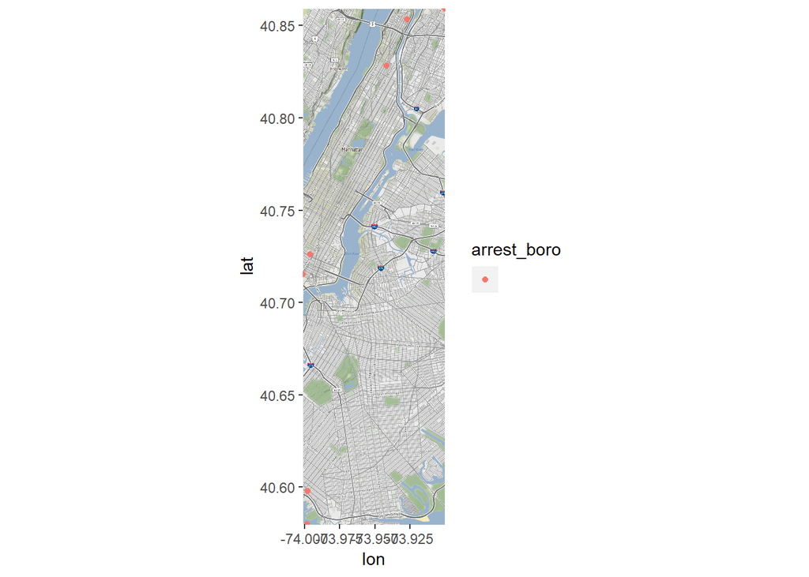

#### PERP_RACE

- *PERP_RACE* has 8 categories with UNKNOWN AND OTHERS. I prefer not to have unknown, especially when there is a category called “Other”. So, I put them together. (But, this may not be a good idea)

|  | perp_race | N | perc |
| --- | --- | --- | --- |
| 1 | BLACK | 2325530 | 0.49 |
| 2 | ASIAN / PACIFIC ISLANDER | 192877 | 0.04 |
| 3 | WHITE | 578861 | 0.12 |
| 4 | WHITE HISPANIC | 1247915 | 0.26 |
| 5 | BLACK HISPANIC | 383589 | 0.08 |
| 6 | UNKNOWN | 48867 | 0.01 |
| 7 | AMERICAN INDIAN/ALASKAN NATIVE | 10448 | 0 |
| 8 | OTHER | 1363 | 0 |

#### AGE_GROUP

- *AGE_GROUP* has 2000, 378, and other numbers that are not descriptive at all. Those non-descriptive numbers were recategorized into **UNKNOWN**

|  | age_group | N |
| --- | --- | --- |
| 1 | 25-44 | 2197846 |
| 2 | 18-24 | 1272805 |
| 3 | 45-64 | 877968 |
| 4 | 65+ | 38910 |
| 5 | &lt;18 | 401730 |
| 6 | UNKNOWN | 191 |

#### New Columns

- *yr* and *yr_mon* were introduced for the analysis

  |  | yr | N |
  | --- | --- | --- |
  | 1 | 2017 | 285418 |
  | 2 | 2016 | 313933 |
  | 3 | 2015 | 338500 |
  | 4 | 2014 | 386787 |
  | 5 | 2013 | 392663 |
  | 6 | 2012 | 395039 |
  | 7 | 2011 | 412131 |
  | 8 | 2010 | 421681 |
  | 9 | 2009 | 421055 |
  | 10 | 2008 | 401368 |

  [output cut: 3 more lines]

  |  | yr_mon | N |
  | --- | --- | --- |
  | 1 | 2017-12 | 20218 |
  | 2 | 2017-11 | 22924 |
  | 3 | 2017-10 | 24672 |
  | 4 | 2017-09 | 22504 |
  | 5 | 2017-08 | 24030 |
  | 6 | 2017-07 | 23386 |
  | 7 | 2017-06 | 23373 |
  | 8 | 2017-05 | 24976 |
  | 9 | 2017-04 | 24967 |
  | 10 | 2017-03 | 25601 |

  [output cut: 146 more lines]

### ANALYSIS & ANSWERING:

#### **1. Has the arrest rate been decreasing from 2015-2018? Describe the trend and defend any statistical tests used to support this conclusion.**

*Population* would be one of the most commonly used candidates to compute the *arrest rate* as followed:
$$Arrest / Population$$
where Arrest represents the number of arrests and Population is total population **(uniformed)**.

Yet, directly using the total population has *shortcomings*, for instance, the uniformed data may mislead the result since it does *not* take the demographic differences among the neighbors into considerations such as ethnicity, social environment, economic status, and such. In the question, the definition of the arrest rate is a bit abstract. The rate could be based on the population or other variables such as race, age, borough, sex, arrest types, and such. Hence, I would also utilize the above-mentioned variables to calculate the arrest rate of each case by year as well as the total population.

Another thing that I would like to mention is that it is not clear if the difference is between the two years, 2015 and 2018 only, or the overall trend across time. To be safe, I will plot the slop chart for the difference between 2015 and 2018; and, I will plot the histogram (bar) to show the trend during the time. Before I jumped into the analysis, I would like to make the following assumption:

- Assumptions:
  - I assume that the population does *not* fluctuate across time. (This is confirmed with the 2018 NYC population data from Statista: the total population is 8,398,748 when 8,242,624 is the total population that I used across the year; reference: https://www.statista.com/statistics/799563/resident-population-of-nyc-by-race/)
  - For simplicity, I *ignore* the traits of the neighbors such as the proportion of each ethnicity, social environment, economic status, and such.
  - I presume that every case is *independent*. This also excludes multiple crime, arrest, cases of a single person.
  - Consecutive observations are *equally spaced*
  - Apply a *discrete-time* index, yearly, (even though this may only hold approximately)

For descriptive statistics, trend analysis on the overall arrest rate, arrest rate difference between 2015 and 2018, and the arrest rate of demographics - race, age group, borough, and gender - and top 5 arrest types.

##### Trend Analysis

- Methodology: Calculate the **arrest rate**, calculated by `number of arrests divided by the total population`, of each month and compare that to each other throughout the year as well as taking a close look at the monthly data.

Based on time series analysis on the overall arrest rate, one could say that the arrest rate has a **decreasing trend** with seasonality. (Note: the number of arrests has been reported in the data also decreases as the time goes)

To have a better understanding of the seasonality, I plotted out the sub seasonality plot; and, it aligns with the Seasonal Trend Decomposition using Loess (STL). Broadly speaking, the arrest rates fluctuate throughout the years; and December has the lowest arrest rate when January has the lowest variation. The lowest arrest rate in December may be explained by the Holiday season.

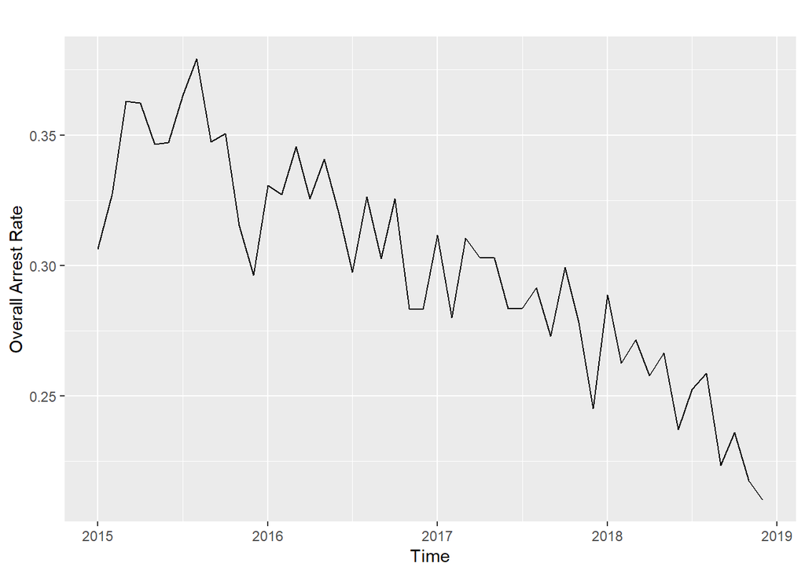

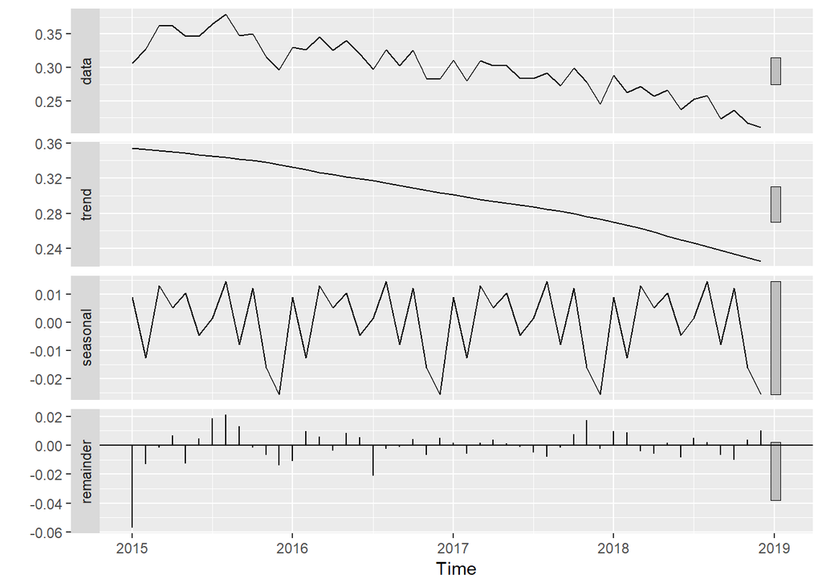

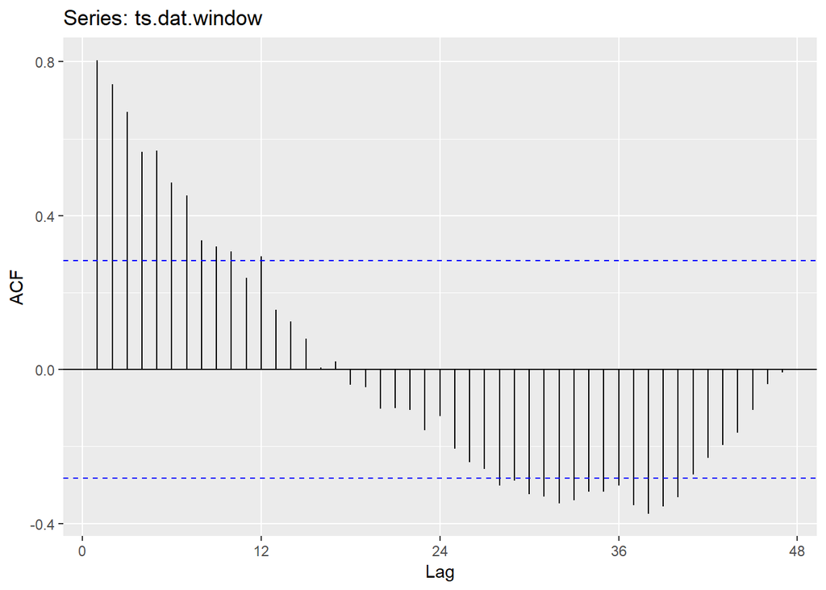

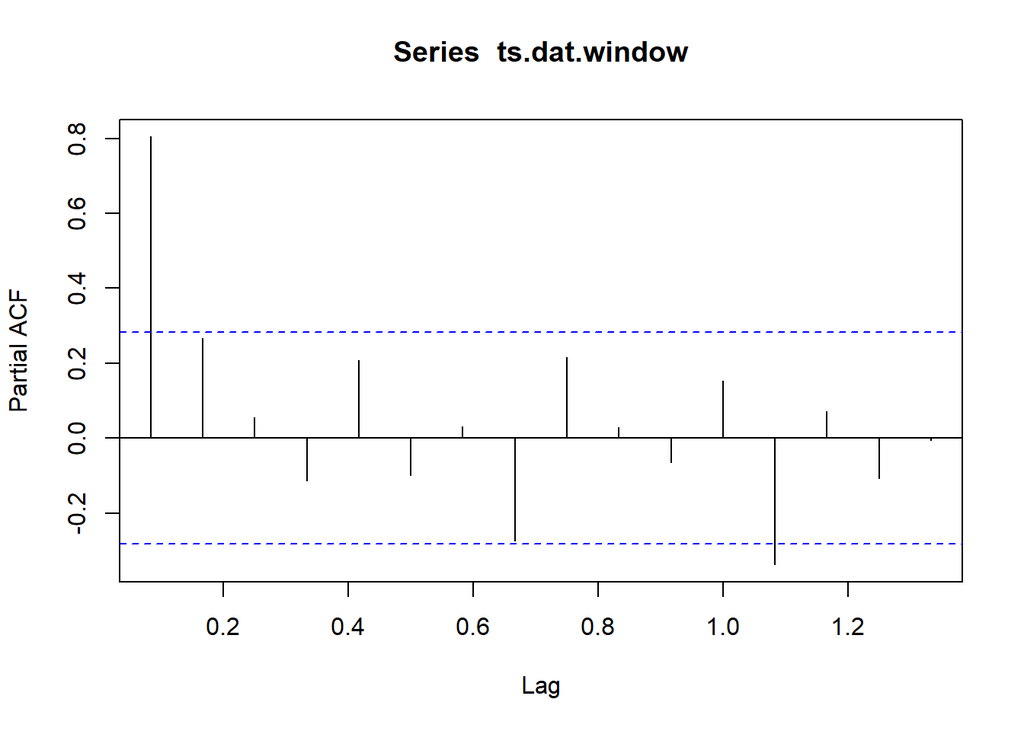

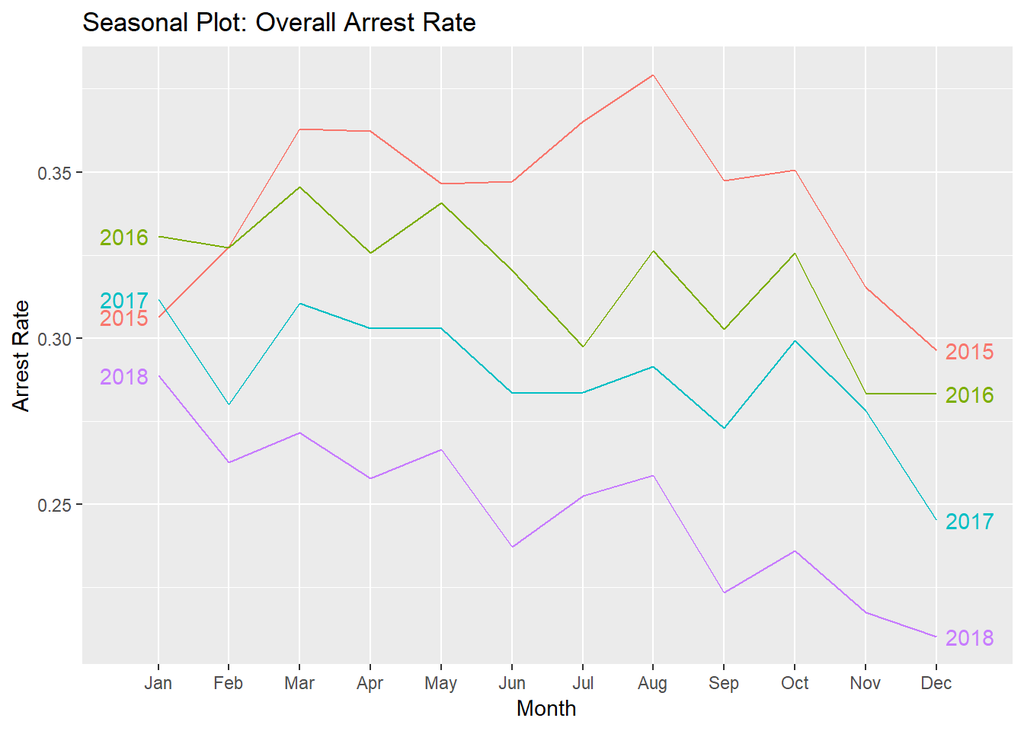

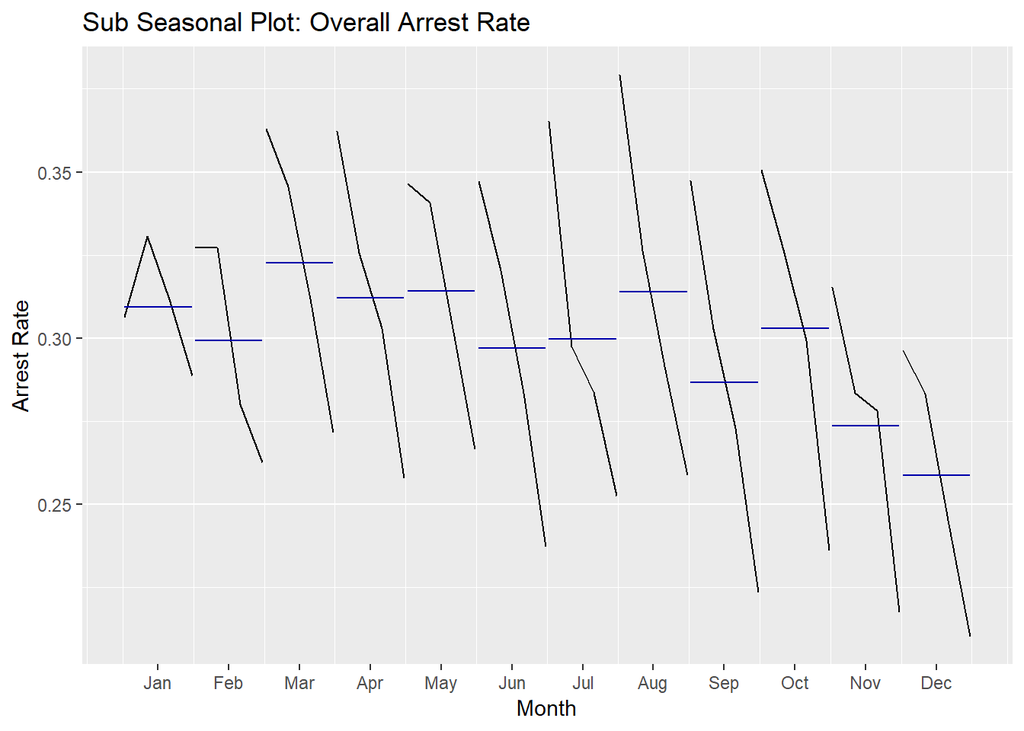

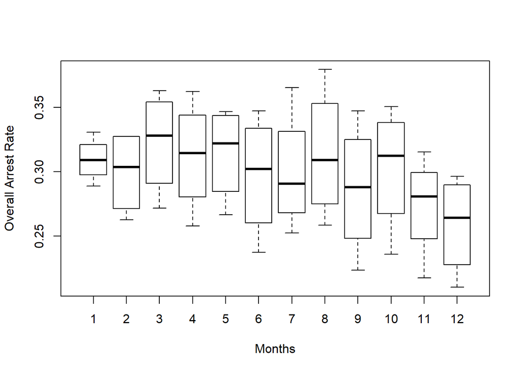

##### Difference Between 2015 & 2018

- Methodology: Calculating the difference between the arrest rates of only those two years: 2015 and 2018. Then, plot out the slope chart to show the relationship.

The result of the slop chart shows that there is not much change between the two years for the arrest rate of race, borough, and gender, while there is an obvious difference for the age group and the offense description.

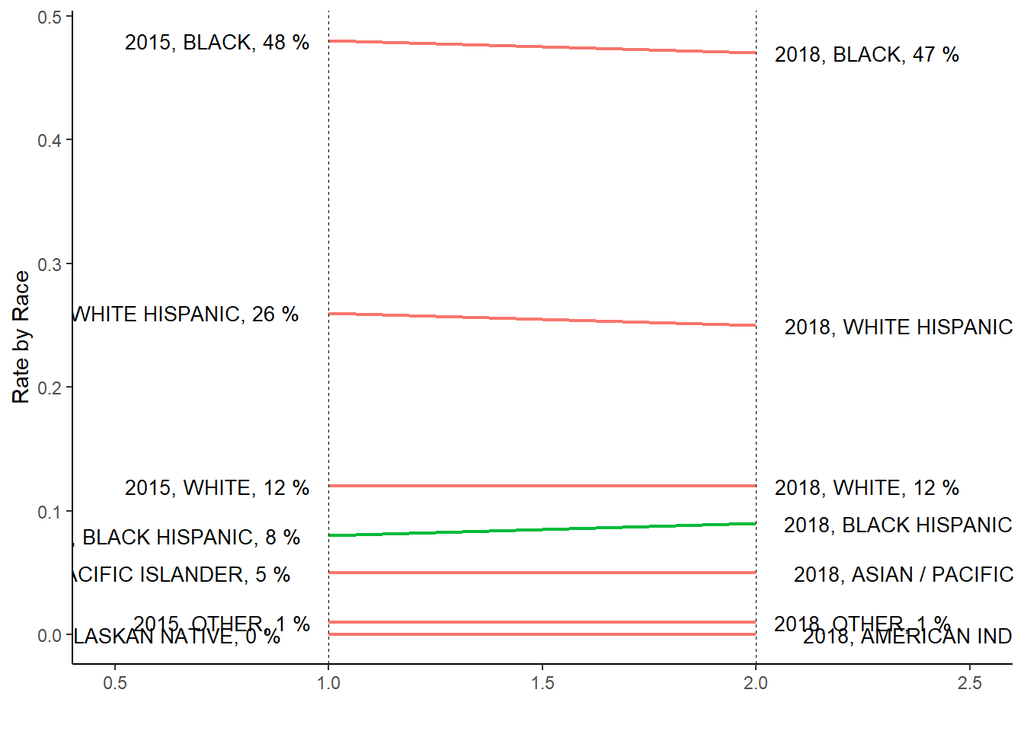

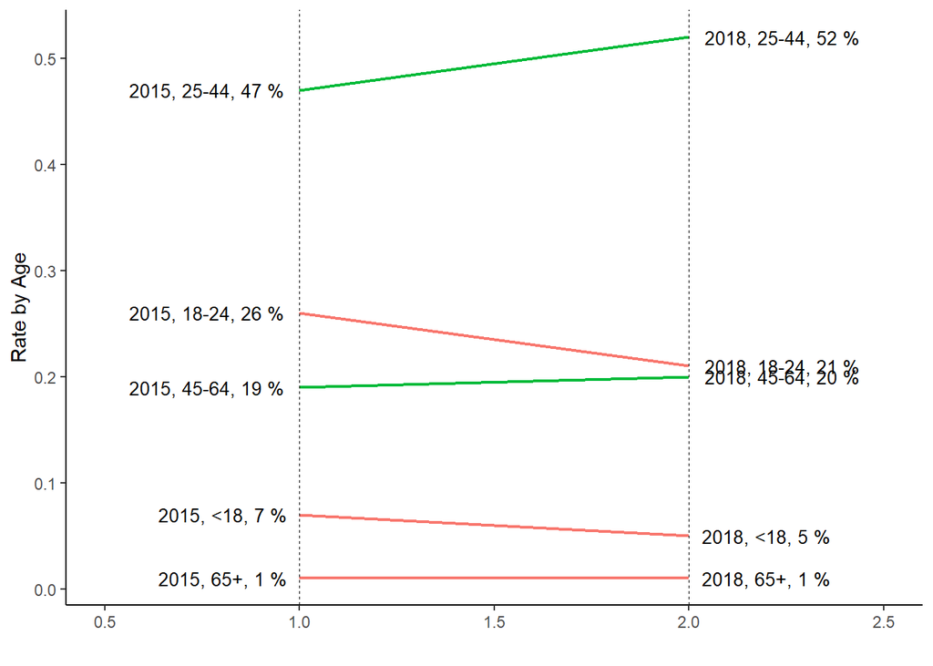

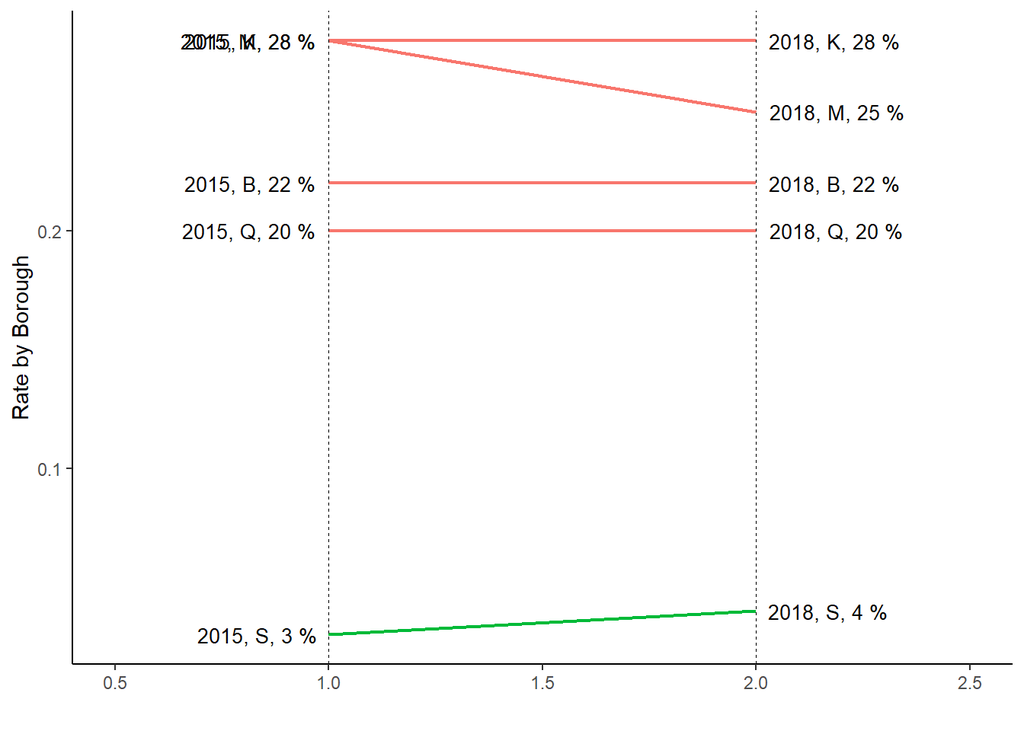

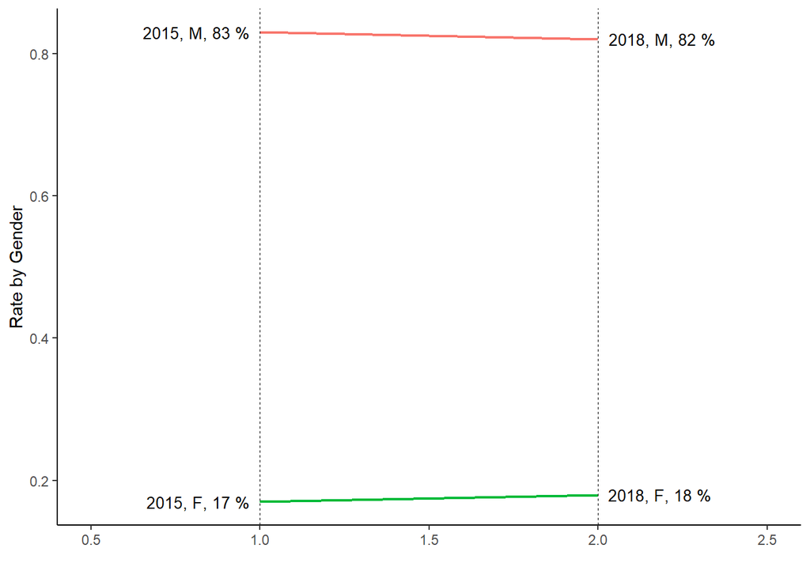

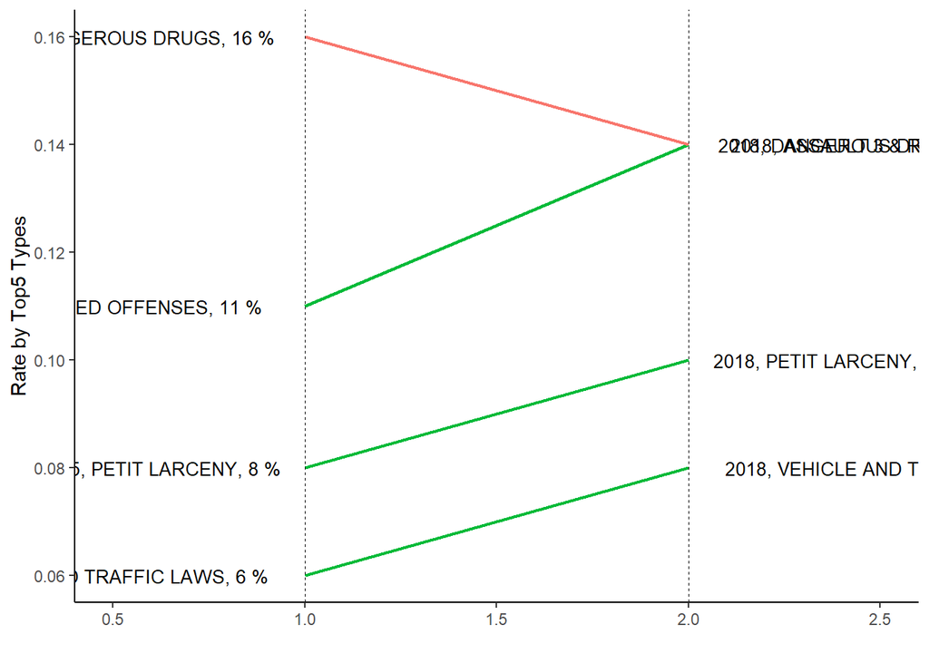

##### Demographic & Top 5 Types

- Methodology: calculate the percentage of each factor of the variables: race, age group, gender, borough, and top 5 types of crime. Then, plot out the histogram of the account rates of each factor throughout the year.

Unlike the trend analysis on the overall arrest rate, the arrest rates based on the demographics do not show distinctive trends but stays almost the same. Still, one could see a change from the arrest rates of age group, borough, and top 5 offense descriptions: the arrest rate of the age group 25-44 increases, while that of 18-24 decreases; and, the assault 3 & related offenses and the vehicle and traffic laws increase as the times goes by, while the dangerous drugs and the other offenses related to theft are decreasing. The most interesting point from this plot would be that felony assault is raised in 2018 as one of the top 5 arrest types when other offenses related to theft is not on the list anymore.

Based on both charts, I could say that the arrest rates of the race and sex do not have any distinctive trends unlike those of the age group, borough, and the types of arrest.

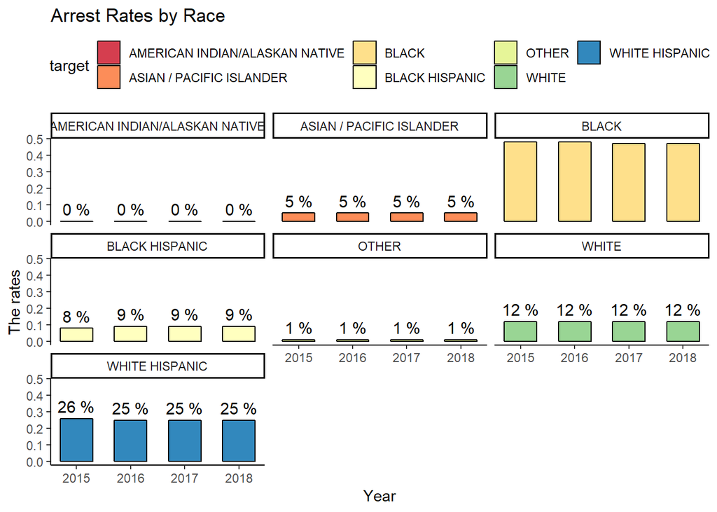

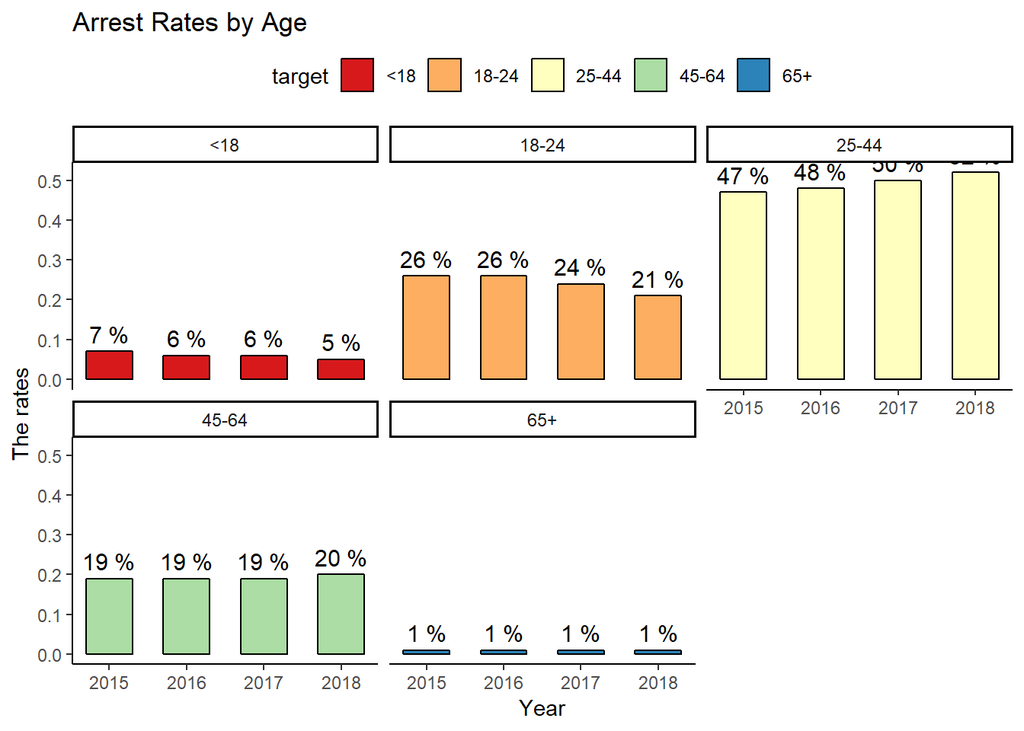

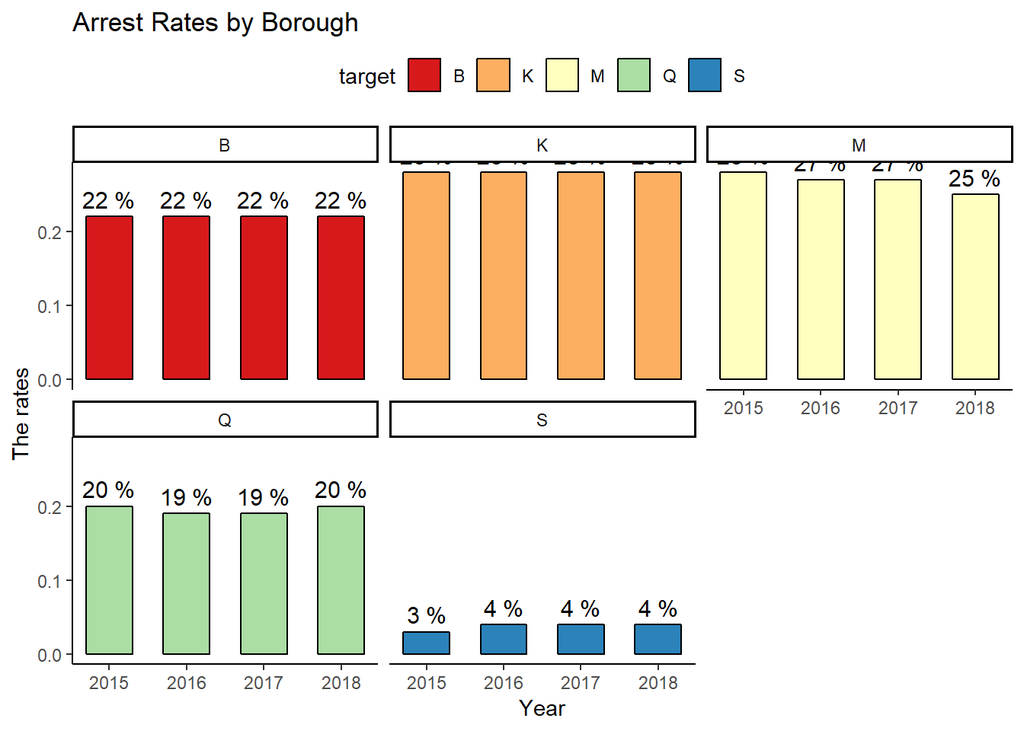

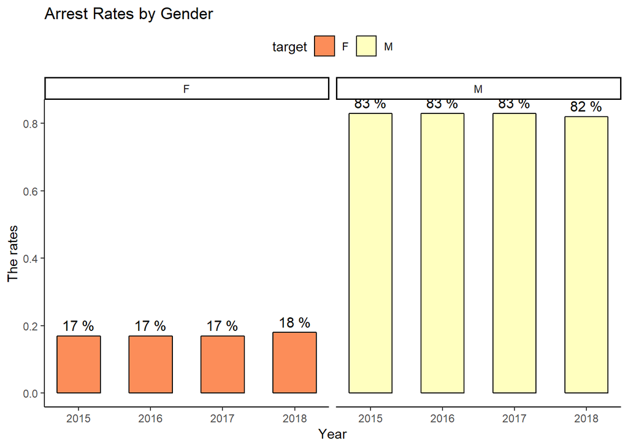

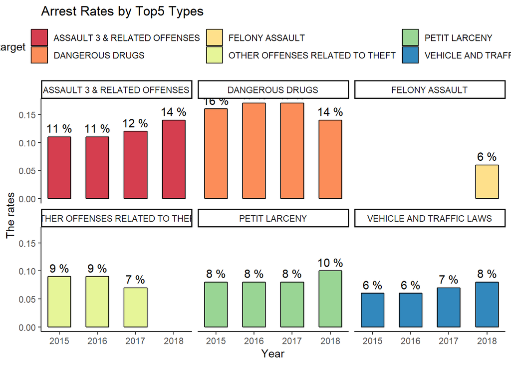

##### Answer

- Methodology: Regression Analysis (linear regression)

In short, the overall arrest rate throughout the time shows the **decreasing trend**; however, the arrest rate of race, gender, age group, borough, and the top 5 arrest types shows the different results: arrest rates of race, borough, and gender do not change much, while the top 5 arrest types and age group display distinctive changes.

As an extension of descriptive statistics, I performed a multivariate linear regression with the following formula:
$$Rate = b_1AgeGroup + b_2Race + b_3Gender + b_4Borough+ b_5Types + b_6Year$$

The result of the linear regression also states that the arrest rates are **decreasing** across the time, holding the above-mentioned variable fixed. Controlling for other variables, one year increase in a year would decrease the arrest rate by **-8.014e-07** on average.

```
FALSE
FALSE Call:
FALSE lm(formula = formula, data = q1.dat)
FALSE
FALSE Residuals:
FALSE        Min         1Q     Median         3Q        Max
FALSE -3.396e-05 -1.013e-05 -3.060e-06  5.320e-06  4.551e-04
FALSE
FALSE Coefficients:
FALSE                                            Estimate Std. Error t value Pr(>|t|)
FALSE (Intercept)                               1.614e-03  5.269e-05  30.627  < 2e-16
FALSE age_group18-24                            6.298e-06  1.196e-07  52.675  < 2e-16
FALSE age_group25-44                            1.304e-05  1.151e-07 113.256  < 2e-16
FALSE age_group45-64                            5.430e-06  1.217e-07  44.629  < 2e-16
FALSE age_group65+                             -2.495e-06  2.352e-07 -10.608  < 2e-16
FALSE perp_raceASIAN / PACIFIC ISLANDER         3.634e-06  4.391e-07   8.276  < 2e-16
FALSE perp_raceBLACK                            1.682e-05  4.274e-07  39.351  < 2e-16
FALSE perp_raceBLACK HISPANIC                   3.294e-06  4.334e-07   7.602 2.93e-14
FALSE perp_raceOTHER                           -1.282e-06  4.879e-07  -2.627  0.00861
FALSE perp_raceWHITE                            5.236e-06  4.310e-07  12.148  < 2e-16
FALSE perp_raceWHITE HISPANIC                   1.013e-05  4.284e-07  23.655  < 2e-16
FALSE perp_sexM                                 9.877e-06  6.577e-08 150.171  < 2e-16
FALSE arrest_boroK                              4.582e-07  8.421e-08   5.441 5.29e-08
FALSE arrest_boroM                              8.951e-07  8.280e-08  10.810  < 2e-16
FALSE arrest_boroQ                             -3.415e-06  8.913e-08 -38.316  < 2e-16
FALSE arrest_boroS                             -8.582e-06  1.377e-07 -62.319  < 2e-16
FALSE ofns_descDANGEROUS DRUGS                  6.634e-06  8.661e-08  76.598  < 2e-16
FALSE ofns_descFELONY ASSAULT                  -5.999e-06  1.033e-07 -58.068  < 2e-16
FALSE ofns_descOTHER OFFENSES RELATED TO THEFT -1.197e-06  1.038e-07 -11.537  < 2e-16
FALSE ofns_descPETIT LARCENY                   -2.500e-06  9.213e-08 -27.132  < 2e-16
FALSE ofns_descVEHICLE AND TRAFFIC LAWS        -4.390e-06  9.996e-08 -43.916  < 2e-16
FALSE yr                                       -8.014e-07  2.613e-08 -30.671  < 2e-16
FALSE
FALSE (Intercept)                              ***
FALSE age_group18-24                           ***
FALSE age_group25-44                           ***
FALSE age_group45-64                           ***
FALSE age_group65+                             ***
FALSE perp_raceASIAN / PACIFIC ISLANDER        ***
FALSE perp_raceBLACK                           ***
FALSE perp_raceBLACK HISPANIC                  ***
FALSE perp_raceOTHER                           **
FALSE perp_raceWHITE                           ***
FALSE perp_raceWHITE HISPANIC                  ***
FALSE perp_sexM                                ***
FALSE arrest_boroK                             ***
FALSE arrest_boroM                             ***
FALSE arrest_boroQ                             ***
FALSE arrest_boroS                             ***
FALSE ofns_descDANGEROUS DRUGS                 ***
FALSE ofns_descFELONY ASSAULT                  ***
FALSE ofns_descOTHER OFFENSES RELATED TO THEFT ***
FALSE ofns_descPETIT LARCENY                   ***
FALSE ofns_descVEHICLE AND TRAFFIC LAWS        ***
FALSE yr                                       ***
FALSE ---
FALSE Signif. codes:  0 '***' 0.001 '**' 0.01 '*' 0.05 '.' 0.1 ' ' 1
FALSE
FALSE Residual standard error: 1.696e-05 on 350946 degrees of freedom
FALSE Multiple R-squared:  0.2215,  Adjusted R-squared:  0.2214
FALSE F-statistic:  4754 on 21 and 350946 DF,  p-value: < 2.2e-16
```

#### **2. What are the top 5 most frequent arrests as described in the column ‘pd_desc’ in 2018? Compare & describe the overall trends of these arrests across time.**

I break the question into two parts: figuring out the top 5 pd_desc in 2018 and looking for the trend. **Here, the question asked about the frequency, which I take it as the number of occurrences, instead of rate. That is, the following analysis is based on the absolute number rather than the rate, calculated by frequency/population**

##### Top 5 Types

There are 351 types of arrests in the column. Yet, there are 304 numbers of arrest types.

As Table 8 shows, the top 5 pd_desc types in 2018 are **Assult 3, Larceny Petit From Open Areas, Traffic, Assault 2&1, and Controlled Substance**.

| pd_desc | N | perc |
| --- | --- | --- |
| ASSAULT 3 | 26611 | 10.82 |
| LARCENY,PETIT FROM OPEN AREAS,UNCLASSIFIED | 23405 | 9.52 |
| TRAFFIC,UNCLASSIFIED MISDEMEAN | 14856 | 6.04 |
| ASSAULT 2,1,UNCLASSIFIED | 11763 | 4.78 |
| CONTROLLED SUBSTANCE, POSSESSION 7 | 9982 | 4.06 |

##### Monthly Top 5 (Additional)

| yr_mon | pd_desc | N | perc |
| --- | --- | --- | --- |
| 2018-12 | LARCENY,PETIT FROM OPEN AREAS,UNCLASSIFIED | 2014 | 11.62 |
| 2018-12 | ASSAULT 3 | 1941 | 11.2 |
| 2018-12 | TRAFFIC,UNCLASSIFIED MISDEMEAN | 996 | 5.75 |
| 2018-12 | ASSAULT 2,1,UNCLASSIFIED | 831 | 4.8 |
| 2018-12 | CONTROLLED SUBSTANCE, POSSESSION 7 | 736 | 4.25 |
| 2018-11 | ASSAULT 3 | 1984 | 11.07 |
| 2018-11 | LARCENY,PETIT FROM OPEN AREAS,UNCLASSIFIED | 1876 | 10.47 |
| 2018-11 | TRAFFIC,UNCLASSIFIED MISDEMEAN | 989 | 5.52 |
| 2018-11 | ASSAULT 2,1,UNCLASSIFIED | 852 | 4.75 |
| 2018-11 | CONTROLLED SUBSTANCE, POSSESSION 7 | 761 | 4.25 |

[output cut: 50 more lines]

|  | pd_desc | N |
| --- | --- | --- |
| 1 | LARCENY,PETIT FROM OPEN AREAS,UNCLASSIFIED | 12 |
| 2 | ASSAULT 3 | 12 |
| 3 | TRAFFIC,UNCLASSIFIED MISDEMEAN | 12 |
| 4 | ASSAULT 2,1,UNCLASSIFIED | 10 |
| 5 | CONTROLLED SUBSTANCE, POSSESSION 7 | 7 |
| 6 | ROBBERY,UNCLASSIFIED,OPEN AREAS | 1 |
| 7 | MARIJUANA, POSSESSION 4 &amp; 5 | 5 |
| 8 | THEFT OF SERVICES, UNCLASSIFIED | 1 |

##### Trend Analysis

On the other hand, the frequency of the Controlled Substance, Possession 7 type is decreasing from 39% to 12%. Until 2015, it was rated as top 3 arrest types; nevertheless, it has made its progress that it is enlisted on bottom 2 since then.

| yr | pd_desc | N | perc | rank | diff |
| --- | --- | --- | --- | --- | --- |
| 2018 | ASSAULT 3 | 26611 | 0.31 | 1 |  |
| 2018 | LARCENY,PETIT FROM OPEN AREAS,UNCLASSIFIED | 23405 | 0.27 | 2 |  |
| 2018 | TRAFFIC,UNCLASSIFIED MISDEMEAN | 14856 | 0.17 | 3 |  |
| 2018 | ASSAULT 2,1,UNCLASSIFIED | 11763 | 0.14 | 4 |  |
| 2018 | CONTROLLED SUBSTANCE, POSSESSION 7 | 9982 | 0.12 | 5 |  |
| 2017 | ASSAULT 3 | 26281 | 0.29 | 1 | 0 |
| 2017 | LARCENY,PETIT FROM OPEN AREAS,UNCLASSIFIED | 23020 | 0.26 | 2 | 0 |
| 2017 | TRAFFIC,UNCLASSIFIED MISDEMEAN | 16298 | 0.18 | 3 | 0 |
| 2017 | CONTROLLED SUBSTANCE, POSSESSION 7 | 12341 | 0.14 | 4 | -1 |
| 2017 | ASSAULT 2,1,UNCLASSIFIED | 11911 | 0.13 | 5 | 1 |

[output cut: 55 more lines]

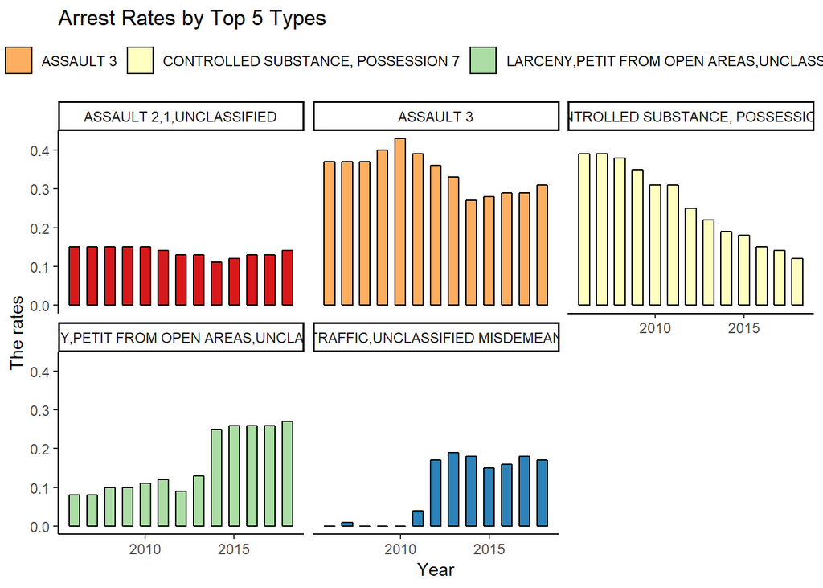

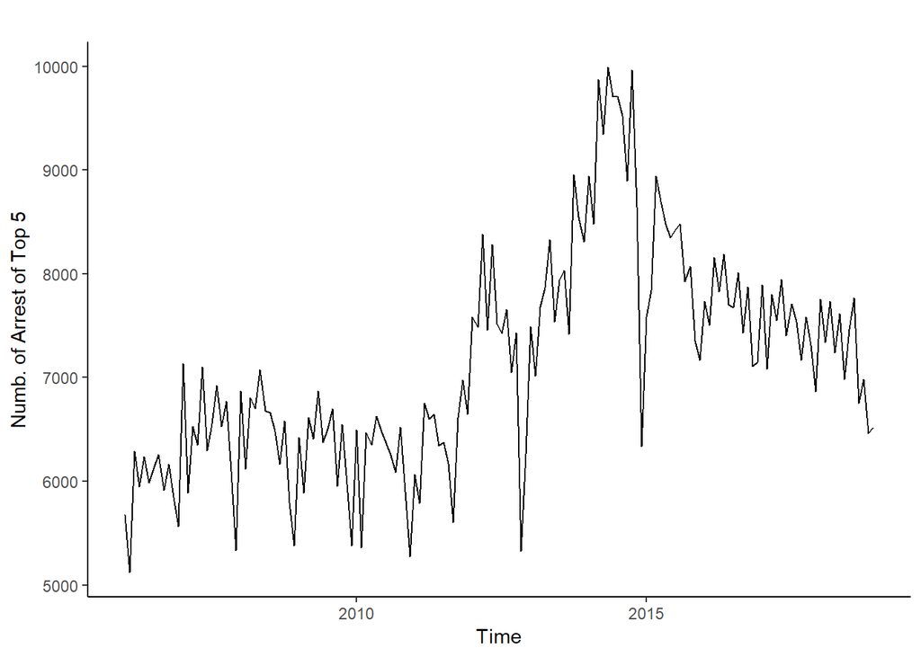

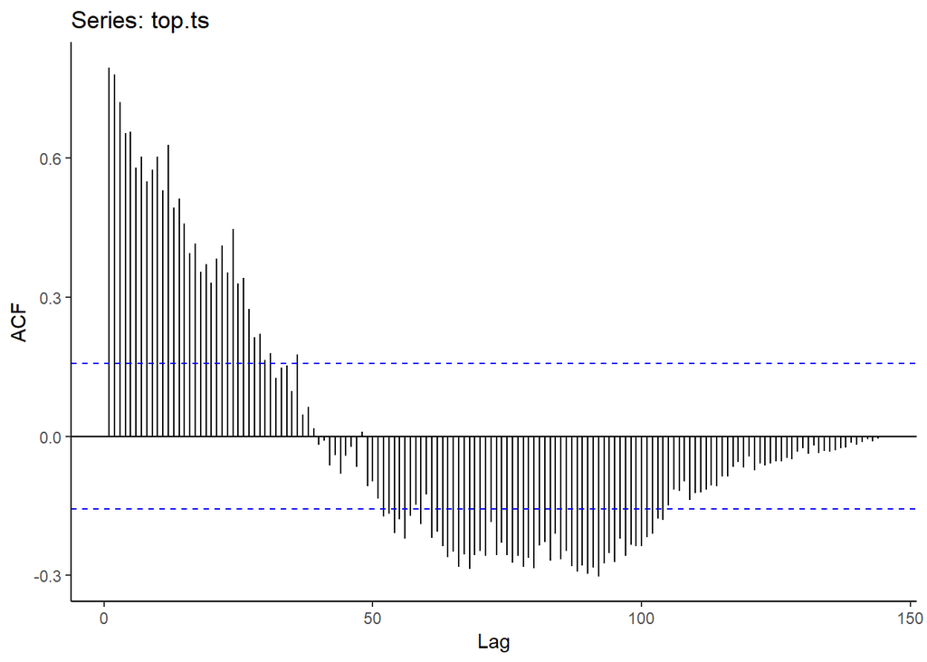

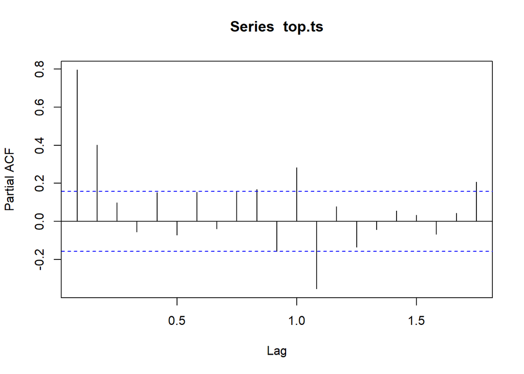

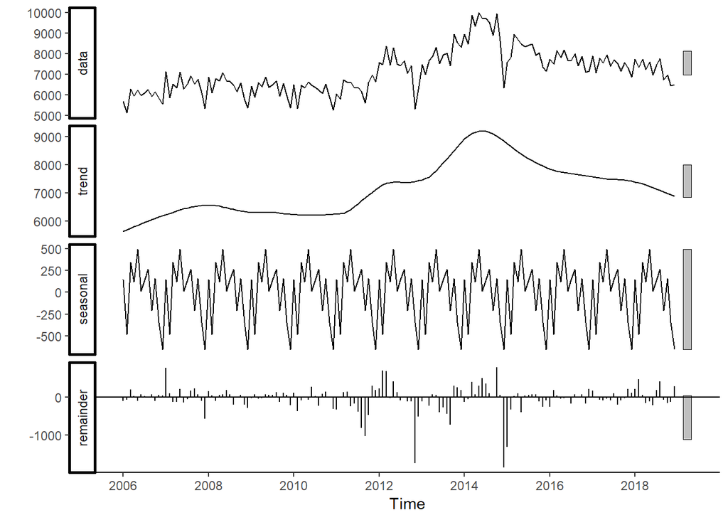

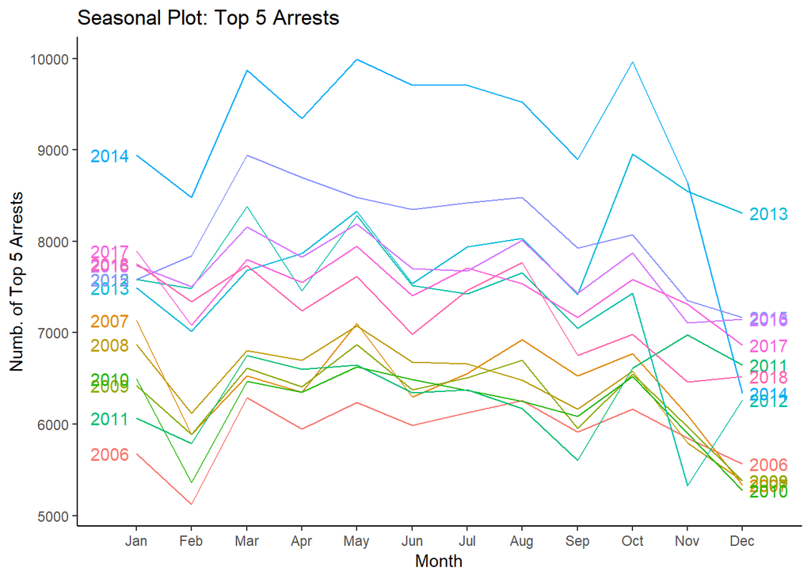

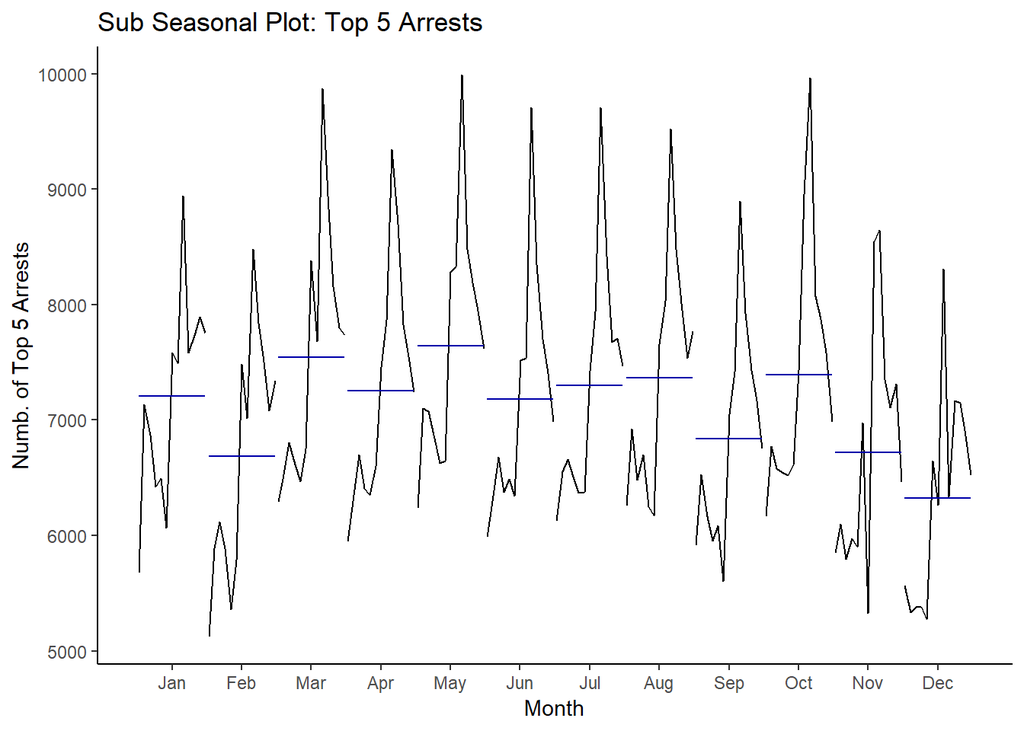

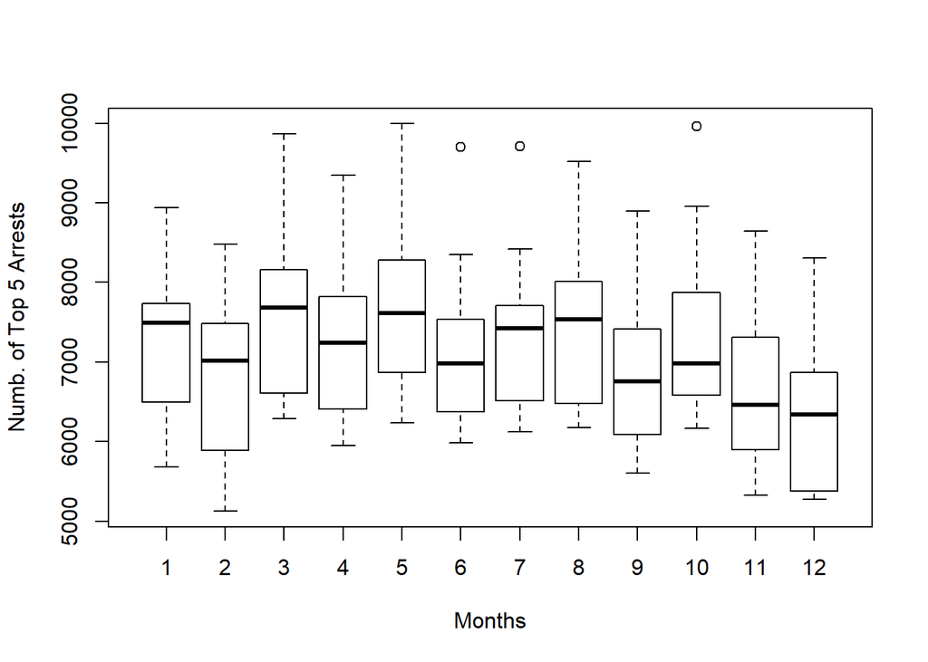

##### Answer

The most frequent pd_desc types in 2018 are **Assult 3, Larceny Petit From Open Areas, Traffic, Assault 2&1, and Controlled Substance**.

Regarding the overall trend of the top 5 arrests, one could say that the trend is **moving from increasing to decreasing starting from 2014 and that there is a high seasonality**. Lastly, December is the month that has the lowest arrest rates throughout the years, when May has the highest.

Still, one could say that the **frequency** of those top 5 types is **increased** due to the fact that the mean of the overall number of arrests of those types is increased compared to that of the beginning year. This could be supported by the plot as followed:

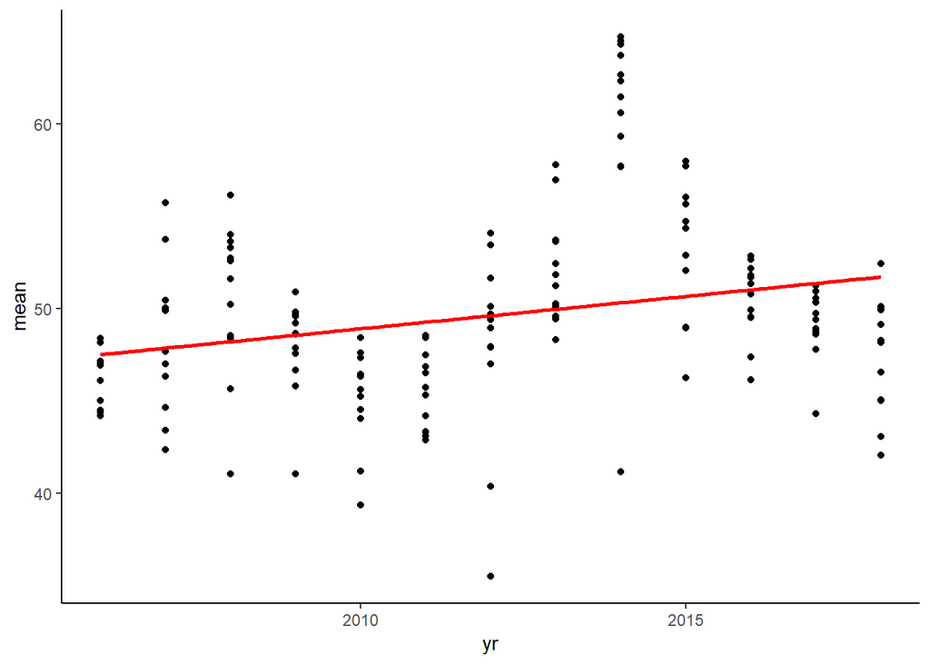

#### **3. If we think of arrests as a sample of total crime, is there more crime in precinct 19 (Upper East Side) than precinct 73 (Brownsville)? Describe the trend, variability and justify any statistical tests used to support this conclusion.**

The question mentioned that the data, sample, could represent the total crime. That is, it is a representative sample that allows me to draw a conclusion of the population based on the analysis of the sample with confidence. Say that, number of arrests can represent the crime rates. With that in mind, the analysis is conducted.

##### 19>73?

- Methodology: calculate the **monthly mean of arrests** of each precinct across the year, then take the **difference** between them. And, plot out the difference by year. Here, I took the mean difference to alleviate the difference between the two districts as well as the difference across the time.

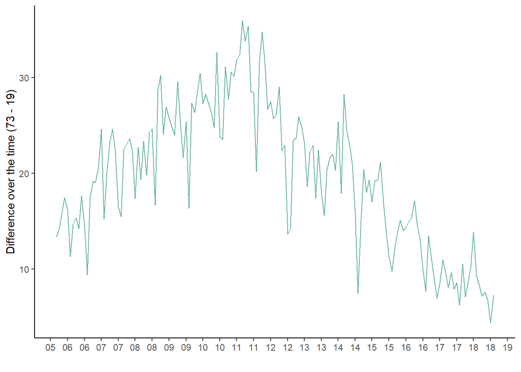